# Biostat M280 Homework 3

Due Mar 1 @ 11:59PM

Xinrui Zhang UID:605231530

Use tidyverse and bash to explore following two data sets.

## Q1 LA City Employee Payroll

The `/home/m280-data/la_payroll/City_Employee_Payroll.csv` file on teaching server contains payroll information of LA City employees in years 2013-2018. It was downloaded from [LA City Controller’s Office](https://controllerdata.lacity.org/Payroll/City-Employee-Payroll/pazn-qyym). Make a Shiny app to facilitate visualization of this data.

1. For efficiency of the Shiny app, you should first pre-process, pare down, tidy, and save the data, e.g., as a compressed RDS file, to be used in the app.

```bash
ln -sf /home/m280data/la_payroll/City_Employee_Payroll.csv LAEmployeePayroll.csv
ls -l NYParkingViolations.csv
```

```
## lrwxrwxrwx. 1 suedez suedez 50 Feb 25 03:30 NYParkingViolations.csv -> /home/m280data/nyc_parking/NYParkingViolations.csv
```

#### A.Load packages and read in cvs file

```r
library(tidyverse)
library(readr)
library(data.table)
library(dplyr)
library(rio)
library(magrittr)
city_ep <- read_csv('LAEmployeePayroll.csv') #city employee and payroll
colnames(city_ep)
```

```
##  [1] "Row ID"                       "Year"
##  [3] "Department Title"             "Payroll Department"
##  [5] "Record Number"                "Job Class Title"
##  [7] "Employment Type"              "Hourly or Event Rate"
##  [9] "Projected Annual Salary"      "Q1 Payments"
## [11] "Q2 Payments"                  "Q3 Payments"
## [13] "Q4 Payments"                  "Payments Over Base Pay"
## [15] "% Over Base Pay"              "Total Payments"
## [17] "Base Pay"                     "Permanent Bonus Pay"
## [19] "Longevity Bonus Pay"          "Temporary Bonus Pay"
## [21] "Lump Sum Pay"                 "Overtime Pay"
## [23] "Other Pay & Adjustments"      "Other Pay (Payroll Explorer)"
## [25] "MOU"                          "MOU Title"
## [27] "FMS Department"               "Job Class"
## [29] "Pay Grade"                    "Average Health Cost"
## [31] "Average Dental Cost"          "Average Basic Life"
## [33] "Average Benefit Cost"         "Benefits Plan"
## [35] "Job Class Link"
```

#### B.Process colnames and chose variables needed then export tibble in a rds file.

```r
names(city_ep) <- str_replace_all(names(city_ep), ".\\(.*\\)", "")
#remove parenthesse
names(city_ep) <- str_replace_all(names(city_ep), " ", "_")
city_ep %<>%
  select(Department_Title, Job_Class_Title,
        Year, Total_Payments, Base_Pay,
        Overtime_Pay, Other_Pay,
        Average_Benefit_Cost)
##save as rds
library(rio)
export(city_ep, "LAep/LAep.rds")
```

0. Visualize any other information you are interested in.

I’d like to see the 6-year average payments composition of a chosen department.

0. Publish your Shiny app to https://www.shinyapps.io and share the link.

See my Shiny app on https://suedez.shinyapps.io/laep/.

## Q2 LA City Parking War

The SQLite database `/home/m280data/la_parking/LA_Parking_Citations.sqlite` on teaching server contains information about parking tickets in LA City. It was downloaded from [LA Open Data Portal](https://data.lacity.org/A-Well-Run-City/Parking-Citations/wjz9-h9np). Connect to the database and answer following questions using plots and summary statistics. In this exercise, you are **not** allowed to load whole data into memory. Use the *transform in database, plot in R* strategy.

1. How many tickets are in this data set? Which time period do these tickets span? Which years have most data?

```r
library("DBI")
library("RSQLite")
```

```bash
ln -sf /home/m280data/la_parking/LA_Parking_Citations.sqlite LAparking.sqlite
ls -l LAparking.sqlite
```

```
## lrwxrwxrwx. 1 suedez suedez 53 Mar  2 06:50 LAparking.sqlite -> /home/m280data/la_parking/LA_Parking_Citations.sqlite
```

```r
if (Sys.info()[["sysname"]] == "Linux") {
  db <- dbConnect(RSQLite::SQLite(),
                  dbname = "LAparking.sqlite")
} else if (Sys.info()[["sysname"]] == "Darwin") {
  db <- dbConnect(RSQLite::SQLite(),
                  dbname = "./LA_Parking_Citations.sqlite")
                  }
dbListTables(db)
```

```
## [1] "latix"
```

```r
LA_sql <- dplyr::tbl(db, "latix") #use tbl function in dplyr package
str(LA_sql)
```

[output not shown]

```r
LA_sql %>% summarise(n = n())
```

```
## # Source:   lazy query [?? x 1]
## # Database: sqlite 3.22.0
## #   [/home/m280data/la_parking/LA_Parking_Citations.sqlite]
##         n
##     <int>
## 1 7656418
```

There are `7656418` tickets in total.

```r
##time range
options(scipen=100) # don't round
LA_sql %>% mutate(time = Issue_Year * 10e7 +
                    Issue_Month * 10e5 +
                    Issue_Day * 10e3 +
                    Issue_Hour * 10e1 +
                    Issue_Minute) %>%
  summarise(Time_begin = min(time),
             Time_end = max(time))
```

```
## # Source:   lazy query [?? x 2]
## # Database: sqlite 3.22.0
## #   [/home/m280data/la_parking/LA_Parking_Citations.sqlite]
##     Time_begin     Time_end
##          <dbl>        <dbl>
## 1 201507020100 201901252358
```

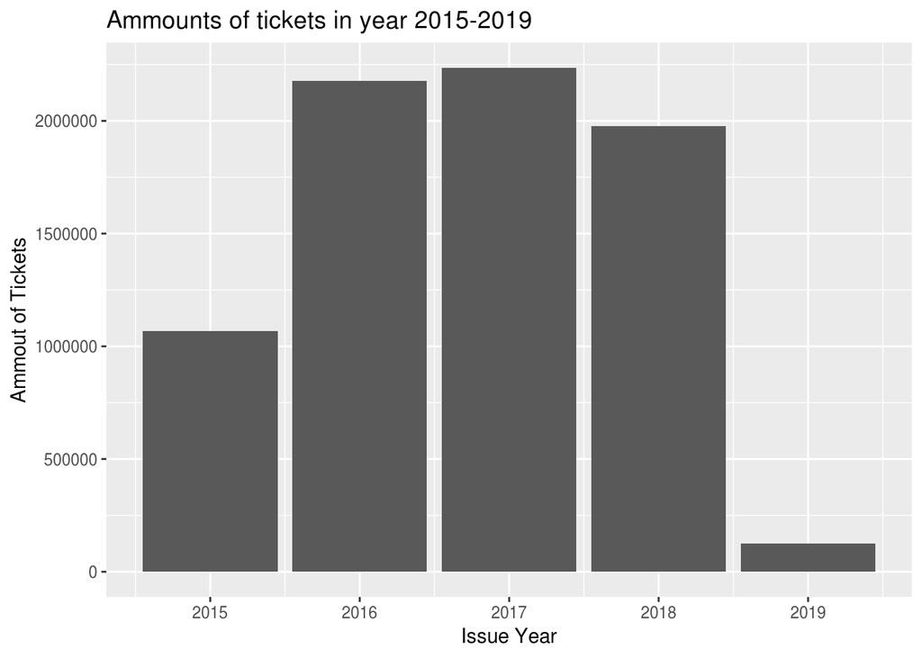

```r
##wich year most tickets
LA_sql %>% group_by(Issue_Year) %>% summarise(n = n()) %>%
  ggplot() +
  geom_bar(stat = 'identity', aes(x = Issue_Year,
                                  y = n)) +
  labs(title = paste('Ammounts of tickets in year 2015-2019'),
        x = 'Issue Year',
        y = 'Ammout of Tickets')
```

As it shown above, the time range is from `1:00,July 2nd, 2015` to `23:58, January 25th, 2019`. The year has most tickets is `2017`.

0. When (which hour, weekday, month day, and month) are you most likely to get a ticket and when are you least likely to get a ticket?

```r
LA_sql %>% group_by(Issue_Month) %>% summarise(n = n()) %>%
  arrange(desc(n)) %>%
  select(Issue_Month, n) %>%
  filter(is.na(Issue_Month) == F) %>%
  collect() -> MONTH
MONTH %>%
  filter(n == max(n) | n == min(n))
```

```
## # A tibble: 2 x 2
##   Issue_Month      n
##         <int>  <int>
## 1           8 752904
## 2           2 512428
```

```r
LA_sql %>% group_by(Issue_Day) %>% summarise(n = n()) %>%
  arrange(desc(n)) %>%
  select(Issue_Day, n) %>%
  filter(is.na(Issue_Day) == F) %>%
  collect() -> DAY
DAY %>%
  filter(n == max(n) | n == min(n))
```

```
## # A tibble: 2 x 2
##   Issue_Day      n
##       <int>  <int>
## 1        13 267419
## 2        31 157356
```

```r
LA_sql %>% group_by(Issue_Wday) %>% summarise(n = n()) %>%
  arrange(desc(n)) %>%
  select(Issue_Wday, n) %>%
  filter(is.na(Issue_Wday) == F) %>%
  collect() -> WDAY
WDAY %>%
  filter(n == max(n) | n == min(n))
```

```
## # A tibble: 2 x 2
##   Issue_Wday       n
##        <dbl>   <int>
## 1          3 1468900
## 2          1  369564
```

```r
LA_sql %>% group_by(Issue_Hour) %>% summarise(n = n()) %>%
  arrange(desc(n)) %>%
  select(Issue_Hour, n) %>%
  filter(is.na(Issue_Hour) == F) %>%
  collect() -> HOUR
HOUR %>%
  filter(n == max(n) | n == min(n))
```

```
## # A tibble: 2 x 2
##   Issue_Hour      n
##        <int>  <int>
## 1         12 975063
## 2          5  53971
```

0. Which car makes received most citations?

```r
LA_sql %>% group_by(Make) %>% summarise(n = n()) %>%
  arrange(desc(n)) %>% filter(is.na(Make) == F) %>%
  select(Make, n)
```

```
## # Source:     lazy query [?? x 2]
## # Database:   sqlite 3.22.0
## #   [/home/m280data/la_parking/LA_Parking_Citations.sqlite]
## # Ordered by: desc(n)
##    Make        n
##    <chr>   <int>
##  1 TOYT  1270804
##  2 HOND   865088
##  3 FORD   666786
##  4 NISS   552070
##  5 CHEV   519495
##  6 BMW    349172
##  7 MERZ   310812
##  8 VOLK   259663
##  9 HYUN   240399
## 10 DODG   225236
## # … with more rows
```

`TOYT` received most citations.

0. How many different colors of cars were ticketed? Which color attracted most tickets?

```r
LA_sql %>% group_by(Color) %>% summarise(n = n()) %>% arrange(desc(n)) %>%
  filter(is.na(Color) == F) %>% collect()
```

```
## # A tibble: 103 x 2
##    Color       n
##    <chr>   <int>
##  1 BK    1652621
##  2 WT    1603566
##  3 GY    1497021
##  4 SL     953903
##  5 BL     591858
##  6 RD     378515
##  7 GN     213197
##  8 BN     148980
##  9 GO      97961
## 10 MR      91279
## # … with 93 more rows
```

There are 103 different colors. The color `black` is the most attractive color, but maybe it is because black is the most common color for cars.

0. What are the most common ticket types?

```r
LA_sql %>% group_by(Violation_Description) %>%
  summarise(n = n()) %>%
  arrange(desc(n))
```

```
## # Source:     lazy query [?? x 2]
## # Database:   sqlite 3.22.0
## #   [/home/m280data/la_parking/LA_Parking_Citations.sqlite]
## # Ordered by: desc(n)
##    Violation_Description        n
##    <chr>                    <int>
##  1 NO PARK/STREET CLEAN   2234699
##  2 METER EXP.             1302155
##  3 RED ZONE                582135
##  4 PREFERENTIAL PARKING    523775
##  5 DISPLAY OF TABS         472750
##  6 NO PARKING              343489
##  7 DISPLAY OF PLATES       211693
##  8 WHITE ZONE              168596
##  9 PARKED OVER TIME LIMIT  156501
## 10 NO STOP/STANDING        138691
## # … with more rows
```

The most common ticket type is `No Park/Street Clean`.

0. How much money was collected on parking tickets in 2016, 2017 and 2018?

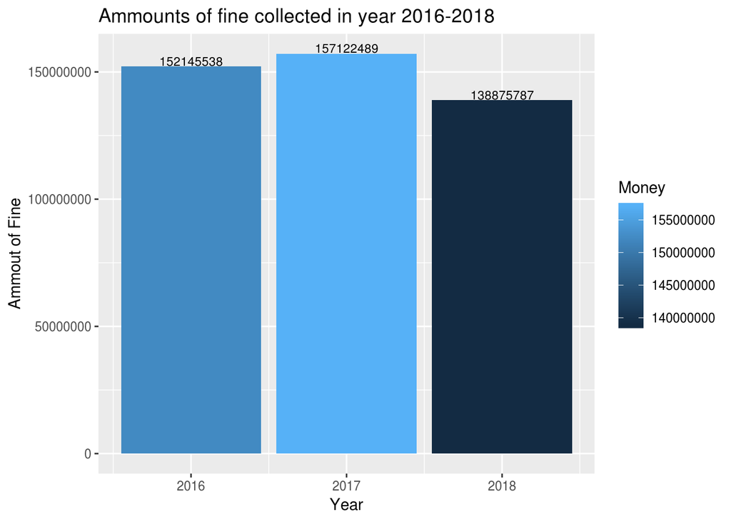

```r
LA_sql %>% filter(Issue_Year == 2016 | Issue_Year == 2017 |
                  Issue_Year == 2018) %>% select(Fine_amount,
                                           Issue_Year) %>%
  group_by(Issue_Year) %>%
  summarise(Money = sum(Fine_amount))  %>%
  ggplot(aes(x = Issue_Year,
              y = Money, fill = Money)) +
  geom_bar(stat = 'identity') +
  geom_text(aes(label = Money,
                vjust = -0.1,
                hjust = 0.5),
            show_guide = FALSE,
            size = 3) +
  labs(title = 'Ammounts of fine collected in year 2016-2018',
        x = 'Year',
        y = 'Ammout of Fine')
```

0. If you’ve been ticketed in LA County, did you find your ticket in this data set?

I don’t even have a car hahaha.

0. Read the blog http://www.brettrics.com/9-million-parking-tickets-la/ and try to reproduce plots using your data.

#### a. Calendar Heatmap

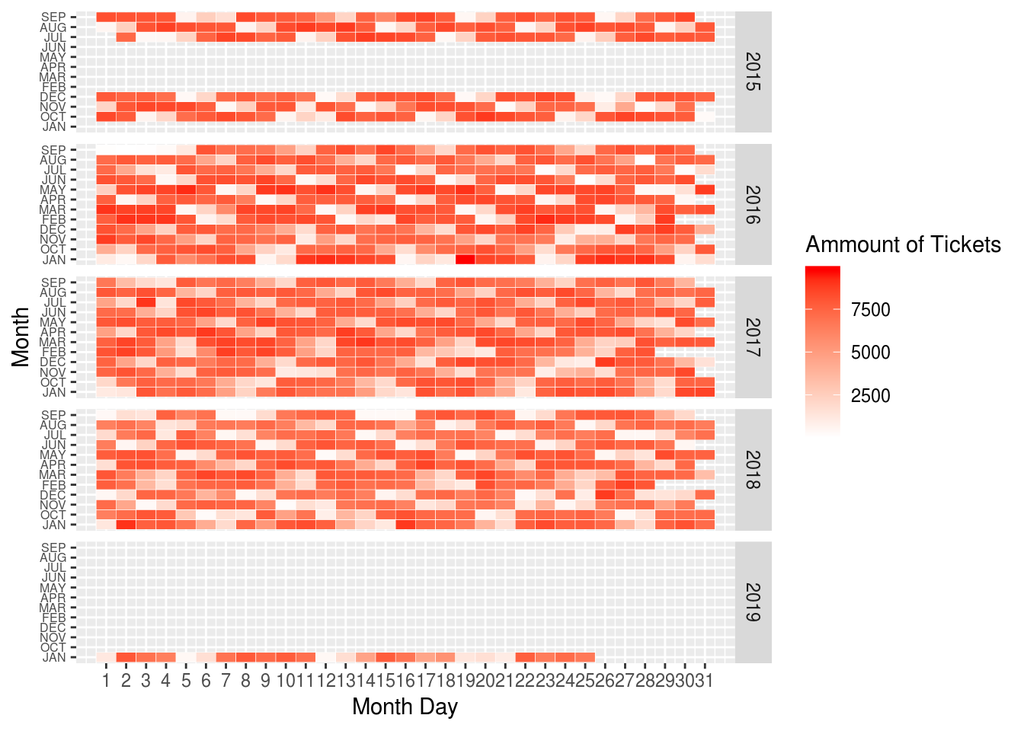

```r
brks <- seq(1, 12, 1)
lbs <- c('JAN', 'FEB', 'MAR', 'APR', 'MAY',
         'JUN', 'JUL', 'AUG', 'SEP',
         'OCT', 'NOV', 'DEC')
brksx <- seq(1, 31, 1)
lbsx <- 1:31
LA_sql %>% group_by(Issue_Year, Issue_Month, Issue_Day) %>%
  summarize(n = n()) %>% filter(is.na(Issue_Year) == F)  %>%
  mutate(Month = paste(Issue_Month)) %>%
  ggplot(aes(x = Issue_Day, y = Month,
         fill = n)) +
  scale_y_discrete(breaks = brks,   # Breaks
         labels = lbs) +
  scale_x_continuous(breaks = brksx,   # Breaks
         labels = lbsx) +
  theme(axis.text.y = element_text(size = 6)) +
  geom_tile(colour = "white") +
  facet_grid(rows = vars(Issue_Year)) +
  coord_cartesian(xlim = c(1, 31)) +
  scale_fill_gradient(low="white", high="red") +
  labs(x = 'Month Day',
        y = 'Month') +
  guides(fill = guide_colorbar(
  title = 'Ammount of Tickets'))
```

#### b.Number of tickets during day hours for the top 7 most common vilation types

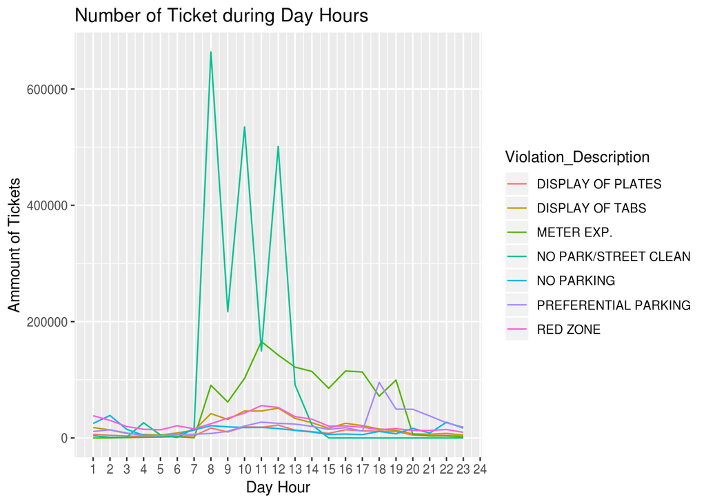

```r
brks <- seq(1, 24, 1)
labs <- seq(1, 24, 1)
LA_sql  %>%
  filter(Violation_Description == 'NO PARK/STREET CLEAN' |
         Violation_Description == 'METER EXP.' |
         Violation_Description == 'RED ZONE' |
         Violation_Description == 'PREFERENTIAL PARKING' |
         Violation_Description == 'DISPLAY OF TABS' |
         Violation_Description == 'NO PARKING' |
         Violation_Description == 'DISPLAY OF PLATES') %>%
  group_by(Violation_Description, Issue_Hour) %>%
  filter(is.na(Issue_Hour) == F) %>%
  summarise(n = n()) %>%
  ggplot(aes(x = Issue_Hour,
             y = n)) +
  geom_line(aes(group = Violation_Description,
                color = Violation_Description)) +
  scale_x_continuous(breaks = brks,   # Breaks
         labels = labs) +
  labs(x = 'Day Hour',
        y = 'Ammount of Tickets',
       title = 'Number of Ticket during Day Hours') +
  guides(fill = guide_colorbar(
  title = 'Violation Type'))
```